# TP Clustering

Partie 3 : Mélanges gaussiens

4modIA / 2022-2023

L’objectif de ce TP est d’illustrer les notions abordées autour des modèles de mélanges gaussiens.

Les librairies R nécessaires pour ce TP :

```r
## Pour faire le TP
library(mclust)
library(ggplot2)
library(gridExtra)
library(FactoMineR)
library(factoextra)
library(reticulate)
library(reshape2)
```

Les librairies Python nécessaires pour ce TP :

```python
import pandas as pd
import numpy as np
import seaborn as sns
import matplotlib.pyplot as plt

from sklearn.preprocessing import StandardScaler
from sklearn.decomposition import PCA
from sklearn.mixture import GaussianMixture as GMM
```

# 1 Application sur données simulées uni-dimensionnelles

**Question :** A l’aide du code suivant, simulez un jeu de données selon un mélange gaussien en $3$ composantes unidimensionnel. Faites varier les différents paramètres (proportions, moyennes et variances).

```r
a <- ...
mu <- c(-a, 0, a)
b <- ...
sigma <- c(b, 0.5, b)
prop <- c(.....)
n <- ....
X <- data.frame(X = c(rnorm(prop[1] * n, mu[1], sigma[1]), rnorm(prop[2] * n, mu[2],
    sigma[2]), rnorm(prop[3] * n, mu[3], sigma[3])))
labeltrue <- c(rep(1, prop[1] * n), rep(2, prop[2] * n), rep(3, prop[3] * n))
```

```r
aux <- seq(-(a + 4), a + 4, 0.01)
Y <- data.frame(x = aux, y1 = (prop[1] * dnorm(aux, mu[1], sigma[1])), y2 = (prop[2] *
    dnorm(aux, mu[2], sigma[2])), y3 = (prop[3] * dnorm(aux, mu[3], sigma[3])))

gvrai <- ggplot(X, aes(x = X)) + geom_histogram(aes(y = after_stat(density)), bins = 100) +
    geom_line(aes(x = x, y = y1), data = Y, col = "red") + geom_line(aes(x = x, y = y2),
    data = Y, col = "blue") + geom_line(aes(x = x, y = y3), data = Y, col = "green")

gvrai
```

**Question :** Estimez les paramètres d’un mélange à $K=3$ classes à l’aide de la fonction `Mclust()` de la librairie `mclust`. Comparez la classification obtenue avec les vrais labels.

```r
# A completer
res <- Mclust(...)
```

**Question :** Représentez la densité de mélange estimée sur l’histogramme de l’échantillon simulé.

```r
# A completer dans y_k <- \pi_k \times \phi(x; \mu_k,\sigma_k^2)

MelEstim <- data.frame(x = aux, y1 = ....., y2 = ....., y3 = ......)
MelEstim <- data.frame(MelEstim, Somme = apply(MelEstim[, 2:4], 1, sum))

gMelEst <- ggplot(X, aes(x = X)) + geom_histogram(aes(y = after_stat(density)), bins = 100) +
    geom_line(aes(x = x, y = y1), data = MelEstim, col = "red") + geom_line(aes(x = x,
    y = y2), data = MelEstim, col = "blue") + geom_line(aes(x = x, y = y3), data = MelEstim,
    col = "green") + geom_line(aes(x = x, y = Somme), data = MelEstim, col = "cyan",
    linetype = "dashed", size = 1.5)
gMelEst
```

**Question :** Calculez les probabilités a posteriori d’appartenance des individus à chacune des trois classes et tracez-les graphiquement.

```r
# dans p, les proba a posteriori d'appartenance
# t_{11},\ldots,t_{n1},t_{12},\ldots,t_{n3}

MelProba <- data.frame(x = rep(aux, 3), p = c(..., ..., ..), class = as.factor(rep(c(1,
    2, 3), each = length(aux))))

gprobapost <- ggplot(MelProba, aes(x = x, y = p, col = class)) + geom_line()

gprobapost
```

**Question :** Tracez les boxplots des probabilités d’appartenance maximales par classe. Vous pouvez vous aider de la fonction `apply()`.

```r
df <- data.frame(lab = ..., probamax = ...)
gprobamax <- ggplot(df, aes(x = lab, y = probamax)) + geom_boxplot()
grid.arrange(gvrai, gMelEst, gprobapost, gprobamax, ncol = 2)
```

# 2 Application sur des données simulées dans $\mathbb{R}^2$

On va ici utiliser les données simulées “ex4.1” disponibles dans la librairie `mclust`. Ces données sont simulées selon un mélange de densités gaussiennes, proposées dans Baudry et al (2010). L’objectif est d’étudier l’impact du choix des formes des mélanges considérées et de la différence d’objectif entre les critères BIC et ICL. On va au travers de ce jeu de données simulées simple appréhender la manipulation des fonctions pour le clustering par mélanges gaussiens avec R et Python.

## 2.1 Avec le logiciel R

On commence ici par charger les données :

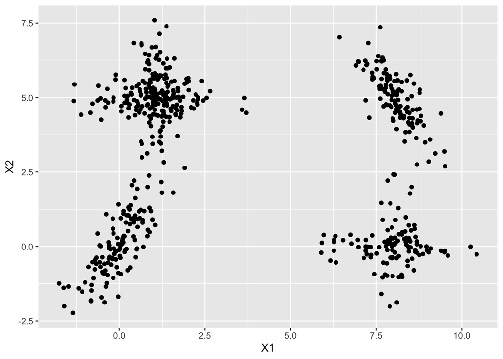

```r
library(mclust)
data(Baudry_etal_2010_JCGS_examples)
Data <- ex4.1
ggplot(Data, aes(x = X1, y = X2)) + geom_point()
```

### 2.1.1 Mélanges gaussiens diagonaux

Dans cette section, on va considérer une collection de modèles de mélanges gaussiens avec un nombre de composantes $K$ variant entre $2$ et $10$ et des matrices de variance-covariance diagonales.

**Question :** A l’aide de la fonction `Mclust()`, estimez les paramètres des mélanges gaussiens considérés. Vous pouvez consulter l’aide de la fonction `mclustModelNames()` pour le choix des formes des mélanges.

```r
# A COMPLETER
resBICdiag <- Mclust(....)
```

**Question :** A l’aide de la fonction `fviz_mclust_bic()`, visualisez le comportement du critère BIC sur la collection de modèles. Quel modèle est sélectionné ? Contrôlez à l’aide de `summary(resBICdiag)`.

```r
fviz_mclust(...., what = ....)
summary(resBICdiag)
```

**Question :** Tracez la classification obtenue sur le nuage de points (vous pouvez utiliser la fonction `fviz_cluster()`). Comment est obtenue cette classification à partir du mélange gaussien retenu ? Quels sont les effectifs par classe ? Contrôlez les probabilités a posterori d’appartenance.

```r
# Visualisation du clustering
fviz_cluster(...)
# Effectifs par classe
table(....)
# Boxplot des probabilités a posteriori maximales
Aux <- data.frame(label = ..., proba = ...)
ggplot(Aux, aes(x = label, y = proba)) + geom_boxplot()
```

**Question :** Quel mélange gaussien est retenu avec le critère ICL ? Vous utiliserez la fonction `mclustICL()`. Etudiez la classification alors déduite.

```r
resICL <- mclustICL(...)
summary(resICL)
```

### 2.1.2 Toutes les formes de mélanges gaussiens

**Question :** Reprenez les questions de la section précédente en considérant ici toutes les formes de mélanges gaussiens. Commentez.

```r
# A COMPLETER
```

## 2.2 Avec le logiciel Python

```python
from sklearn.mixture import GaussianMixture as GMM
Datapy=r.Data
```

Avec la fonction `GMM` de `sklearn.mixture` sous python, on n’a pas à notre disposition toutes les formes de mélanges gaussiens comme avec la librairie `mclust`. Quelles sont les formes disponibles ici ?

### 2.2.1 Ajustement avec un mélange de forme diagonale

Dans cette section, on va considérer un mélange gaussien avec un nombre de composantes $K$ variant entre $2$ et $20$ et des matrices de variance-covariance diagonales.

**Question :** A l’aide de la fonction `GMM`, estimez les paramètres des mélanges gaussiens considérés.

```python
# A COMPLETER
K_components = np.arange(......)
models = [GMM(K, covariance_type=....., random_state=0).fit(......) for K in K_components]
```

*Question :* Visualisez le comportement des critères BIC et AIC sur la collection de modèles. Quel modèle est sélectionné par le critère BIC ?

```python
crit = pd.DataFrame({
    "K" : np.arange(2, 21),
    "BIC" : [m.bic(Datapy) for m in models],
    "AIC" : [m.aic(Datapy) for m in models],
})
critdf=pd.melt(crit, id_vars=['K'], value_vars=['BIC', 'AIC'])

import plotly.express as px
fig = px.line(critdf, x='K', y='value', color='variable')
fig.show()
```

**Question :** Tracez la classification (obtenue à partir de la sélection par le critère BIC) sur le nuage de points. Quels sont les effectifs par classe ? Contrôlez les probabilités a posterori d’appartenance.

```python
# A COMPLETER

# Modele retenu par BIC
U=[m.bic(Datapy) for m in models]
u=np.argmin(U)
  #covariances = models[u].covariances_
  #means = models[u].means_
  #models[u].weights_

probapost = models[u].predict_proba(Datapy)
labels=models[u].fit_predict(Datapy)
probamax=[np.max(probapost[x,:]) for x in range(len(Datapy))]

pd.crosstab(labels,"freq")
```

```python
# Classif sur le nuage de points
df = pd.DataFrame({
    "X" : Datapy.X1,
    "Y" : Datapy.X2,
    "labels" : pd.Categorical(labels)
})

import plotly.express as px
fig = px.scatter(df,x="X", y="Y", color="labels", symbol="labels")
fig.show()

# boxplot des probamax
aux=pd.DataFrame({'probamax':probamax,'labels':labels},columns = ['probamax', 'labels'])

import plotly.express as px
fig = px.box(aux, x="labels", y="probamax")
fig.show()
```

**Question :** Déterminez la valeur du critère ICL pour chaque modèle en compétition. Quel mélange gaussien est retenu avec le critère ICL ? Etudiez la classification alors déduite.

```python
# A COMPLETER
# pour avoir ICL
ICL = [m.bic(Datapy) - (2*sum(np.log( np.max(m.predict_proba(Datapy),1) ))) for m in models]
crit=crit.assign(ICL=ICL)
critdf=pd.melt(crit, id_vars=['K'], value_vars=['BIC', 'AIC','ICL'])

...
```

### 2.2.2 Ajustement avec un mélange gaussien de forme générale

**Question :** Reprenez l’étude en considérant un mélange gaussien avec des matrices de variance-covarinaces totalement libres. Commentez.

```python
# A COMPLETER
```

# 3 Etude des données de vins

On reprend dans ce TP les données `wine` disponibles sur la page moodle du cours. On charge ici les données.

```r
wine <- read.table("wine.txt", header = T)
wine$Qualite = as.factor(wine$Qualite)
wine$Type = factor(wine$Type, labels = c("blanc", "rouge"))

wineinit <- wine
wine[, -c(1, 2)] <- scale(wine[, -c(1, 2)], center = T, scale = T)

head(wine)
```

```
     Qualite  Type      AcidVol    AcidCitr     SO2lbr      SO2tot     Densite
1352  medium rouge  1.638714588 -1.92626362 -1.2083376 -1.15967786 -0.46497450
5493  medium blanc -0.068544417 -1.35617574 -0.7004747 -0.85707581 -0.33499781
5153  medium blanc -0.800226847 -0.59605856  0.5409681 -0.02047014  1.32391517
5308  medium blanc -0.007570881  0.92417581  1.7824108  1.27893867  1.08790487
3866  medium blanc  0.419243870  0.03737243 -0.5311870  0.99413674  0.03783006
694   medium rouge  0.785085086  0.03737243 -0.4747578  0.19313131  1.27260858
          Alcool
1352  1.14546909
5493 -1.12092616
5153 -1.29526426
5308 -1.29526426
3866  0.09944051
694  -0.94658806
```

On fait une ACP pour la visualisation des résultats dans la suite

```r
resacp <- PCA(wine, quali.sup = c(1, 2), scale.unit = TRUE, graph = FALSE)
```

Et on prépare aussi pour Python

```python
winepy=r.wine
winequant=winepy
winequant=winequant.drop(columns=['Type','Qualite'])
from sklearn.preprocessing import StandardScaler
scaler = StandardScaler();
scaler.fit(winequant);
winequant=scaler.transform(winequant)

from sklearn.decomposition import PCA
mypca = PCA(n_components=3);
mypca.fit(winequant);
dataPCA=mypca.fit_transform(winequant)
```

**Question :** Déterminez une classification de ces données à l’aide d’un modèle de mélange. Comparez votre résultat avec les classifications obtenues dans les TP précédents (avec Kmeans, CAH).

```r
# A FAIRE
```